# Lab 2 - Data Management for Housing Analysis

Esteban Lopez Ochoa** *URP 5313 - Urban Housing Policy and Analysis* University of Texas at San Antonio

10/13/2021

- Part 1: Using & manipulating data from an external source
- Part 2: Indentifying key housing issues and data gaps

BY the end of this lab, the student is expected to have a broad knowledge and basic hands on experience of the methods to import and analyse data relating to housing issues.

### Part 1: Using data from an external source

Data is comonly first downloaded from an external source and then loaded into R for procesing. This script shows how to load data from an external source and how to process it in order to create outputs (i.e. maps, tables, etc.) that will serve to inform policymaking.

###### Loading an external Data Source: The Opportunity Insights Project

Opportunity insights is a not-for-profit organization directed by Prof. Raj Chetty (Harvard University) developed with the aim to **“…identify barriers to economic opportunity…”**. As housing scholars, we know that for a increasingly larger portion of the population, housing is a steping stone over which famkilies can build wealth and create stability and opportunities for their families. Hence much of the barriers to economic opportunities identified in the OI project overlap with the barriers for attaining a health housing situation. In specific the neighborhood dimension of the OI project contains many important findings that can provide useful insights when embarking in a housing analysis journey (see more in: https://opportunityinsights.org/neighborhoods/)

For our excercise, we will use the neighborhood variables at the census tract level.This data set can be downloaded manually from:https://opportunityinsights.org/data/, by selecting `census tract` geographic level and then downloading the excel file for ‘Neighborhood characteris by Census Tracts’. Alternativelly, the data can be directedly downloaded and imported directly using the following:

```r
library(data.table)
d1<-fread("https://opportunityinsights.org/wp-content/uploads/2018/10/tract_covariates.csv")
d2<-fread("tract_covariates.csv")

identical(d1,d2)
```

```
## [1] FALSE
```

```r
rm(d2)
```

Always it is useful to have a good idea of the strcuture of the data, namely, what variables are there available, what format are they stored, and what limitations (i.e. missing, incomplete cases, etc.) the data might have. This can be achieve by:

1. Looking at the data source metadata. In the case of the OI data this information can be found at: https://opportunityinsights.org/wp-content/uploads/2019/07/Codebook-for-Table-9.pdf
2. Looking at the structure of the imported data and corroborating if all variables were imported correctinly, this can be done by:

```r
str(d1) # provides a general structure of the data (variable names, type, forst 6 observations)
```

```
## Classes 'data.table' and 'data.frame':   74044 obs. of  38 variables:
##  $ state                       : int  1 1 1 1 1 1 1 1 1 1 ...
##  $ county                      : int  1 1 1 1 1 1 1 1 1 1 ...
##  $ tract                       : int  20100 20200 20300 20400 20500 20600 20700 20801 20802 20900 ...
##  $ cz                          : int  11101 11101 11101 11101 11101 11101 11101 11101 11101 11101 ...
##  $ czname                      : chr  "Montgomery" "Montgomery" "Montgomery" "Montgomery" ...
##  $ hhinc_mean2000              : num  68639 57243 75648 74852 96175 ...
##  $ mean_commutetime2000        : num  26.2 24.8 25.3 23 26.2 ...
##  $ frac_coll_plus2000          : num  0.156 0.147 0.224 0.23 0.321 ...
##  $ frac_coll_plus2010          : num  0.254 0.267 0.164 0.253 0.375 ...
##  $ foreign_share2010           : num  0.00995 0.01634 0.0271 0.01508 0.04649 ...
##  $ med_hhinc1990               : num  27375 19000 29419 37891 41516 ...
##  $ med_hhinc2016               : int  66000 41107 51250 52704 52463 63750 45234 74603 61242 44591 ...
##  $ popdensity2000              : num  196 566 624 714 530 ...
##  $ poor_share2010              : num  0.105 0.1476 0.0804 0.0632 0.0596 ...
```

[output cut: 25 more lines]

```r
summary(d1) # provides a detailed summary statistic by variable (inlcuding the presence of NA's)
```

```
##      state           county           tract              cz
##  Min.   : 1.00   Min.   :  1.00   Min.   :   100   Min.   :  100
##  1st Qu.:13.00   1st Qu.: 29.00   1st Qu.: 10303   1st Qu.:11600
##  Median :28.00   Median : 63.00   Median : 47801   Median :19700
##  Mean   :28.31   Mean   : 85.82   Mean   :260196   Mean   :21276
##  3rd Qu.:42.00   3rd Qu.:109.00   3rd Qu.:480100   3rd Qu.:32000
##  Max.   :72.00   Max.   :840.00   Max.   :993000   Max.   :39400
##                                                    NA's   :950
##     czname          hhinc_mean2000   mean_commutetime2000 frac_coll_plus2000
##  Length:74044       Min.   :  7240   Min.   : 2.50        Min.   :0.0000
##  Class :character   1st Qu.: 57366   1st Qu.:22.03        1st Qu.:0.1106
##  Mode  :character   Median : 71706   Median :26.16        Median :0.1869
##                     Mean   : 80328   Mean   :26.95        Mean   :0.2378
##                     3rd Qu.: 94675   3rd Qu.:31.05        3rd Qu.:0.3254
##                     Max.   :434369   Max.   :80.03        Max.   :1.0000
##                     NA's   :1651     NA's   :1627         NA's   :1580
##  frac_coll_plus2010 foreign_share2010 med_hhinc1990    med_hhinc2016
##  Min.   :0.0000     Min.   :0.0000    Min.   :  4999   Min.   :  2499
##  1st Qu.:0.1308     1st Qu.:0.0230    1st Qu.: 22257   1st Qu.: 38698
##  Median :0.2183     Median :0.0671    Median : 29807   Median : 52292
##  Mean   :0.2692     Mean   :0.1209    Mean   : 32178   Mean   : 58810
##  3rd Qu.:0.3706     3rd Qu.:0.1689    3rd Qu.: 39408   3rd Qu.: 71851
##  Max.   :1.0000     Max.   :1.0000    Max.   :150001   Max.   :250001
##  NA's   :796        NA's   :1666      NA's   :1624     NA's   :1090
##  popdensity2000      poor_share2010   poor_share2000   poor_share1990
##  Min.   :     0.00   Min.   :0.0000   Min.   :0.0000   Min.   :0.0000
##  1st Qu.:    95.56   1st Qu.:0.0592   1st Qu.:0.0502   1st Qu.:0.0488
##  Median :   755.01   Median :0.1161   Median :0.0957   Median :0.0955
##  Mean   :  1983.55   Mean   :0.1517   Mean   :0.1285   Mean   :0.1322
##  3rd Qu.:  2000.98   3rd Qu.:0.2056   3rd Qu.:0.1715   3rd Qu.:0.1752
##  Max.   :205382.19   Max.   :1.0000   Max.   :1.0000   Max.   :1.0000
##  NA's   :1305        NA's   :907      NA's   :1628     NA's   :1608
##  share_white2010  share_black2010  share_hisp2010   share_asian2010
##  Min.   :0.0000   Min.   :0.0000   Min.   :0.0000   Min.   :0.0000
##  1st Qu.:0.4121   1st Qu.:0.0132   1st Qu.:0.0244   1st Qu.:0.0039
##  Median :0.7341   Median :0.0433   Median :0.0634   Median :0.0116
##  Mean   :0.6311   Mean   :0.1407   Mean   :0.1629   Mean   :0.0376
##  3rd Qu.:0.8918   3rd Qu.:0.1517   3rd Qu.:0.1897   3rd Qu.:0.0350
##  Max.   :1.0000   Max.   :1.0000   Max.   :1.0000   Max.   :1.0000
##  NA's   :618      NA's   :618      NA's   :618      NA's   :1856
```

[output cut: 33 more lines]

```
##  Min.   :      0     Min.   :      0       Min.   :     0.0
##  1st Qu.:   6454     1st Qu.:   2280       1st Qu.:   314.9
##  Median :  42216     Median :  16915       Median :  2190.0
##  Mean   : 111950     Mean   :  58554       Mean   :  5236.6
##  3rd Qu.: 122815     3rd Qu.:  57716       3rd Qu.:  5284.3
##  Max.   :2826437     Max.   :1794186       Max.   :543333.3
##  NA's   :1364        NA's   :1364          NA's   :406
##  ann_avg_job_growth_2004_2013 job_density_2013
##  Min.   :-0.607               Min.   :      0.0
##  1st Qu.:-0.019               1st Qu.:     55.9
##  Median : 0.009               Median :    410.8
##  Mean   : 0.015               Mean   :   2152.8
##  3rd Qu.: 0.041               3rd Qu.:   1369.3
##  Max.   : 1.336               Max.   :2905290.3
##  NA's   :3244                 NA's   :1326
```

```r
class(d1)
```

```
## [1] "data.table" "data.frame"
```

###### Most common data manipulation operations

```r
d1[,table(czname)] # variable exploration - counts
```

```
## czname
##                                      Aberdeen                Abilene
##                    950                     15                     56
##                    Ada                  Aiken              Ainsworth
##                     21                    124                      3
##             Alamogordo                Alamosa                 Albany
##                     21                     14                    338
##            Albuquerque             Alexandria              Allentown
##                    210                     47                    156
##                 Alpena                 Alpine                Altoona
##                     33                      6                    108
##                  Altus               Amarillo               Americus
##                     14                     69                     20
##                  Amery              Amsterdam              Anchorage
##                     16                     35                     92
##                Andrews                Ardmore              Asheville
##                     18                     33                    112
##                Ashland                 Athens                Atlanta
##                     20                     34                    847
##               Atlantic                 Atmore                 Auburn
##                     12                     21                     42
##                 Aurora                 Austin             Bainbridge
##                     30                    384                     13
##                  Baker            Bakersfield              Baltimore
##                      1                    151                    672
##                 Bangor              Bardstown               Barnwell
##                     91                     18                     18
##                 Barrow           Bartlesville             Batesville
##                      3                     47                     16
##            Baton Rouge               Beaumont                Beckley
##                    171                    132                     40
##               Beeville             Bellingham                 Beloit
##                     11                     34                      3
##                Bemidji                   Bend          Bennettsville
##                     32                     34                     17
##                 Berlin                Bethany                 Bethel
##                     36                      6                      4
##             Big Rapids             Big Spring          Big Stone Gap
##                     33                     17                     22
##               Billings             Birmingham               Bismarck
```

[output cut: 404 more lines]

```
##                     43                     54                      9
##                Willmar             Wilmington                 Wilson
##                     27                    263                     51
##             Winchester                 Winder               Winfield
##                     27                     64                     16
##             Winnemucca                 Winner          Winston-Salem
##                      5                      4                    138
##             Wolf Point               Woodward                Worland
##                      4                      9                      5
##            Worthington                 Yakima                Yankton
##                     19                     53                     12
##             Yazoo City                   York             Youngstown
##                      9                      8                    207
##                   Yuma             Zanesville
##                     86                     42
```

```r
d1[,.N, by=.(czname)] #alternative
```

```
##          czname   N
##   1: Montgomery 105
##   2:     Mobile 165
##   3:    Eufaula  20
##   4: Tuscaloosa  75
##   5: Birmingham 260
##  ---
## 682:     Casper  22
## 683:   Riverton  10
## 684: Torrington   6
## 685:    Worland   5
## 686:       Lusk   1
```

```r
d1[czname=="San Antonio",] # filtering
```

```
##      state county  tract    cz      czname hhinc_mean2000 mean_commutetime2000
##   1:    48     13 960100 31301 San Antonio       60732.74             34.62542
##   2:    48     13 960201 31301 San Antonio       64234.03             38.15882
##   3:    48     13 960202 31301 San Antonio       60457.78             40.78081
##   4:    48     13 960300 31301 San Antonio       44444.81             32.67863
##   5:    48     13 960401 31301 San Antonio       64706.38             38.63244
##  ---
## 458:    48    493    402 31301 San Antonio       71383.45             32.79148
## 459:    48    493    403 31301 San Antonio       85851.36             38.71663
## 460:    48    493    404 31301 San Antonio       85851.35             38.71663
## 461:    48    493    500 31301 San Antonio       68277.06             39.02169
## 462:    48    493    600 31301 San Antonio       66052.52             36.31079
##      frac_coll_plus2000 frac_coll_plus2010 foreign_share2010 med_hhinc1990
##   1:         0.07980718         0.14155470        0.03678823      19885.00
##   2:         0.13307986         0.12666325        0.05550146      19713.00
```

[output cut: 105 more lines]

```r
SA_OI<- d1[czname=="San Antonio",] # filtering + object creation (subsetting)

SA_OI[is.na(hhinc_mean2000),] #identifying cases with NAs
```

```
##    state county  tract    cz      czname hhinc_mean2000 mean_commutetime2000
## 1:    48     29 980001 31301 San Antonio             NA                   NA
## 2:    48     29 980004 31301 San Antonio             NA                   NA
##    frac_coll_plus2000 frac_coll_plus2010 foreign_share2010 med_hhinc1990
## 1:                 NA                 NA                NA            NA
## 2:                 NA                 NA                NA            NA
##    med_hhinc2016 popdensity2000 poor_share2010 poor_share2000 poor_share1990
## 1:            NA      0.1262074             NA             NA             NA
## 2:            NA      0.0000000             NA             NA             NA
##    share_white2010 share_black2010 share_hisp2010 share_asian2010
## 1:            0.75               0           0.25              NA
## 2:              NA              NA             NA              NA
##    share_black2000 share_white2000 share_hisp2000 share_asian2000
## 1:               0          0.9375         0.0625              NA
## 2:              NA              NA             NA              NA
##    gsmn_math_g3_2013 rent_twobed2015 singleparent_share2010
## 1:          3.809690              NA                     NA
## 2:          3.184527              NA                     NA
##    singleparent_share1990 singleparent_share2000 traveltime15_2010 emp2000
## 1:                     NA                      0                NA      NA
## 2:                     NA                     NA                NA      NA
##    mail_return_rate2010 ln_wage_growth_hs_grad jobs_total_5mi_2015
## 1:                    0                     NA                7813
## 2:                   NA                     NA              185592
##    jobs_highpay_5mi_2015 popdensity2010 ann_avg_job_growth_2004_2013
## 1:                  2228     0.08171938                           NA
## 2:                 74498     0.00000000                  0.006048175
##    job_density_2013
## 1:         1.961265
## 2:      1161.904800
```

```r
SA_OI<- SA_OI[is.na(hhinc_mean2000)==FALSE,]

SA_OI[, ones:=1] # variable creation
SA_OI[hhinc_mean2000<=quantile(hhinc_mean2000,probs = 0.5), bellow_medianIncome:=1 ] # variable creation by codition
SA_OI[is.na(bellow_medianIncome),bellow_medianIncome:=0] # variable value replacement by condition

SA_OI[, med_hhinc_growth1990_2006:=((med_hhinc2016-med_hhinc1990)/med_hhinc1990)*100]# variable creation by a mathematical manipulation of other variables.
```

###### More advanced data manipulation

```r
#let's load a simple map
library(tidycensus)
census_api_key("0d539976d5203a96fa55bbf4421110d4b3db3648")# you must acquired your own key at http://api.census.gov/data/key_signup.html
```

```
## To install your API key for use in future sessions, run this function with `install = TRUE`.
```

```r
bexar_medincome <- get_acs(geography = "tract", variables = "B19013_001",
                state = "TX", county = "Bexar", geometry = TRUE)
bexar_medincome
```

```
## Simple feature collection with 366 features and 5 fields
## Geometry type: MULTIPOLYGON
## Dimension:     XY
## Bounding box:  xmin: -98.80655 ymin: 29.11444 xmax: -98.1169 ymax: 29.76071
## Geodetic CRS:  NAD83
## First 10 features:
##          GEOID                                      NAME   variable estimate
## 1  48029190601 Census Tract 1906.01, Bexar County, Texas B19013_001    46818
## 2  48029181100    Census Tract 1811, Bexar County, Texas B19013_001    64930
## 3  48029140700    Census Tract 1407, Bexar County, Texas B19013_001    36222
## 4  48029180602 Census Tract 1806.02, Bexar County, Texas B19013_001    38389
## 5  48029140800    Census Tract 1408, Bexar County, Texas B19013_001    43299
## 6  48029170200    Census Tract 1702, Bexar County, Texas B19013_001    25755
## 7  48029171502 Census Tract 1715.02, Bexar County, Texas B19013_001    28705
## 8  48029131505 Census Tract 1315.05, Bexar County, Texas B19013_001    58171
## 9  48029181003 Census Tract 1810.03, Bexar County, Texas B19013_001    37832
## 10 48029190901 Census Tract 1909.01, Bexar County, Texas B19013_001    39583
##      moe                       geometry
## 1  14436 MULTIPOLYGON (((-98.52602 2...
## 2   6521 MULTIPOLYGON (((-98.56225 2...
## 3   6656 MULTIPOLYGON (((-98.47348 2...
## 4   7038 MULTIPOLYGON (((-98.56606 2...
## 5   3656 MULTIPOLYGON (((-98.4778 29...
## 6   7141 MULTIPOLYGON (((-98.5283 29...
## 7   5549 MULTIPOLYGON (((-98.58759 2...
## 8   7415 MULTIPOLYGON (((-98.37527 2...
## 9  10918 MULTIPOLYGON (((-98.57325 2...
## 10 10690 MULTIPOLYGON (((-98.50712 2...
```

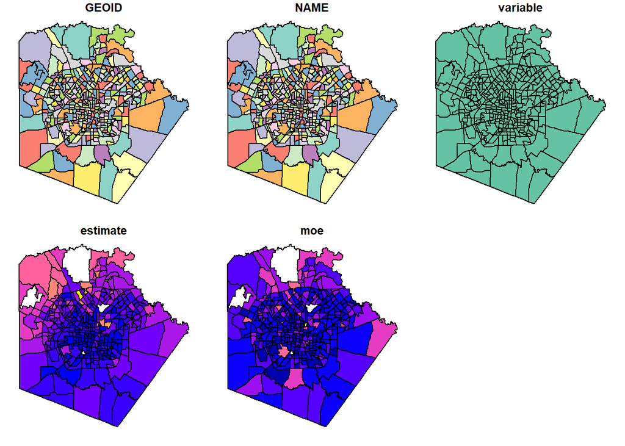

```r
plot(bexar_medincome)
```

```r
#merge SA_OI data with the map

head(SA_OI) ; head(bexar_medincome)
```

```
##    state county  tract    cz      czname hhinc_mean2000 mean_commutetime2000
## 1:    48     13 960100 31301 San Antonio       60732.74             34.62542
## 2:    48     13 960201 31301 San Antonio       64234.03             38.15882
## 3:    48     13 960202 31301 San Antonio       60457.78             40.78081
## 4:    48     13 960300 31301 San Antonio       44444.81             32.67863
## 5:    48     13 960401 31301 San Antonio       64706.38             38.63244
## 6:    48     13 960402 31301 San Antonio       64270.25             28.57449
##    frac_coll_plus2000 frac_coll_plus2010 foreign_share2010 med_hhinc1990
## 1:         0.07980718         0.14155470        0.03678823      19885.00
## 2:         0.13307986         0.12666325        0.05550146      19713.00
## 3:         0.07519342         0.07265869        0.09224874      19708.57
## 4:         0.06431026         0.05623032        0.05276382      13390.00
## 5:         0.01538462         0.05718271        0.15620705      23125.00
## 6:         0.20873444         0.19833298        0.03047091      23125.00
##    med_hhinc2016 popdensity2000 poor_share2010 poor_share2000 poor_share1990
```

[output cut: 55 more lines]

```
## Simple feature collection with 6 features and 5 fields
## Geometry type: MULTIPOLYGON
## Dimension:     XY
## Bounding box:  xmin: -98.56606 ymin: 29.36662 xmax: -98.44832 ymax: 29.54044
## Geodetic CRS:  NAD83
##         GEOID                                      NAME   variable estimate
## 1 48029190601 Census Tract 1906.01, Bexar County, Texas B19013_001    46818
## 2 48029181100    Census Tract 1811, Bexar County, Texas B19013_001    64930
## 3 48029140700    Census Tract 1407, Bexar County, Texas B19013_001    36222
## 4 48029180602 Census Tract 1806.02, Bexar County, Texas B19013_001    38389
## 5 48029140800    Census Tract 1408, Bexar County, Texas B19013_001    43299
## 6 48029170200    Census Tract 1702, Bexar County, Texas B19013_001    25755
##     moe                       geometry
## 1 14436 MULTIPOLYGON (((-98.52602 2...
## 2  6521 MULTIPOLYGON (((-98.56225 2...
## 3  6656 MULTIPOLYGON (((-98.47348 2...
## 4  7038 MULTIPOLYGON (((-98.56606 2...
## 5  3656 MULTIPOLYGON (((-98.4778 29...
## 6  7141 MULTIPOLYGON (((-98.5283 29...
```

```r
SA_OI[,GEOID:=paste0(state,"0",county,tract)] #creating a GEOID variable to have a common variable between the two data sets

#check variable classes

class(bexar_medincome$GEOID)
```

```
## [1] "character"
```

```r
class(SA_OI$GEOID)
```

```
## [1] "character"
```

```r
table(bexar_medincome$GEOID %in%  SA_OI$GEOID) # checking overlap
```

```
##
## FALSE  TRUE
##     2   364
```

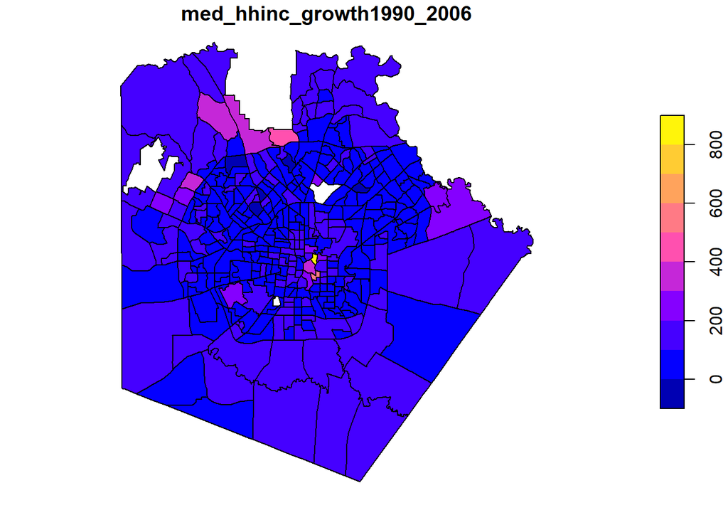

```r
# merge/join by GEOIDS
bexar_medincome2<-merge(bexar_medincome,SA_OI,by="GEOID")


#plotting

plot(bexar_medincome2[,"med_hhinc_growth1990_2006"])# fast plotting
```

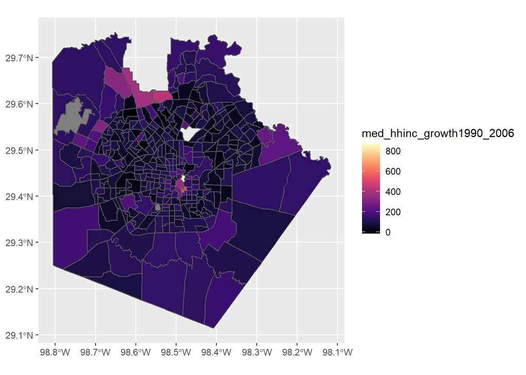

```r
library(ggplot2);library(viridis) # prettier plotting
ggplot(bexar_medincome2)+
  geom_sf(aes(fill=med_hhinc_growth1990_2006))+
  scale_fill_viridis(option = "magma") +
  scale_color_viridis(option = "magma")
```

```r
library(leaflet) # dynamic plotting
pal <- colorQuantile("YlOrRd", domain = bexar_medincome2$med_hhinc_growth1990_2006, n = 5)

leaflet(bexar_medincome2)%>%
  addProviderTiles(provider = providers$CartoDB.Positron)%>%
  addPolygons(fillColor = ~pal(med_hhinc_growth1990_2006),label = ~med_hhinc_growth1990_2006,color=~pal(med_hhinc_growth1990_2006),fillOpacity = 0.5,weight = 0.1)%>%
  addLegend(pal = pal,values = ~med_hhinc_growth1990_2006,opacity = 1)
```

[interactive chart not shown]

### Part 2: Indentifying key housing issues and data gaps

###### Exploratory data analysis

The objective of an Exploratory Data Analysis (EDA) is to explore and reveal relationships between variables available in the data as a way to provide initial insights on how a particular dataset can be useful to inform the researcher about a particular problem.

In housing analysis, we know that there are two main types of variables that we may be able to acquire data about:

1. Housing sympthoms variables: Variables that provide information about a sympthom or issue directly related to the health status of a housing market. Examples of these variables are: - Affordability Index: assess the levels of affordability in a particular area (can be defined in many ways) - housing demand - New construction starts: assess the levels of dynamism of housing supply - Housing prices: asssess the level of housing demand - Housing tenure rates: assess the status of housing demand between the sales and renting market - Eviction/ foreclosure counts: assess the level of how critical is a household’ housing situation

2.Housing exogenous forces: variables that provide information about socio-economic forces that affect the housing market, but are normally contextual and outside of the control of planning/housing actors. Examples of these variables are: - Employment/Unemployment: Variables related to job creation or destruction. - Private investment: variables related the private companies investing in land aquisition or job creation - Interest rates: indicator of how attractive can be the mortgage sector - Mortgage placements: variables related to the lending market - Insurance variables: variables related to how the insurance market is covering housing market mortgages/rental leases - Climate related variables: variables related to climate events affecting the housing market (e.g., flooding maps, etc.) - Demographic variables: variables that alone don’t tell much about housing, but need to be spatially referenced or combined with other housing variables to do so.

*Excercise 1*: Let’s create two objects listing the variables according to the to previous groups. Then create a `data.table` object for each of the variable types.

```
##  [1] "state"                        "county"
##  [3] "tract"                        "cz"
##  [5] "czname"                       "hhinc_mean2000"
##  [7] "mean_commutetime2000"         "frac_coll_plus2000"
##  [9] "frac_coll_plus2010"           "foreign_share2010"
## [11] "med_hhinc1990"                "med_hhinc2016"
## [13] "popdensity2000"               "poor_share2010"
## [15] "poor_share2000"               "poor_share1990"
## [17] "share_white2010"              "share_black2010"
## [19] "share_hisp2010"               "share_asian2010"
## [21] "share_black2000"              "share_white2000"
## [23] "share_hisp2000"               "share_asian2000"
## [25] "gsmn_math_g3_2013"            "rent_twobed2015"
## [27] "singleparent_share2010"       "singleparent_share1990"
## [29] "singleparent_share2000"       "traveltime15_2010"
## [31] "emp2000"                      "mail_return_rate2010"
## [33] "ln_wage_growth_hs_grad"       "jobs_total_5mi_2015"
## [35] "jobs_highpay_5mi_2015"        "popdensity2010"
## [37] "ann_avg_job_growth_2004_2013" "job_density_2013"
```

*Excercise 2*: Alternativelly, in the case we want to keep all variables in the same object, how can we identify them?

```
##  [1] "state"                        "county"
##  [3] "tract"                        "cz"
##  [5] "czname"                       "hhinc_mean2000"
##  [7] "mean_commutetime2000"         "frac_coll_plus2000"
##  [9] "frac_coll_plus2010"           "foreign_share2010"
## [11] "med_hhinc1990"                "med_hhinc2016"
## [13] "popdensity2000"               "poor_share2010"
## [15] "poor_share2000"               "poor_share1990"
## [17] "share_white2010"              "share_black2010"
## [19] "share_hisp2010"               "share_asian2010"
## [21] "share_black2000"              "share_white2000"
## [23] "share_hisp2000"               "share_asian2000"
## [25] "gsmn_math_g3_2013"            "rent_twobed2015"
## [27] "singleparent_share2010"       "singleparent_share1990"
## [29] "singleparent_share2000"       "traveltime15_2010"
## [31] "emp2000"                      "mail_return_rate2010"
## [33] "ln_wage_growth_hs_grad"       "jobs_total_5mi_2015"
## [35] "jobs_highpay_5mi_2015"        "popdensity2010"
## [37] "ann_avg_job_growth_2004_2013" "job_density_2013"
```

Now that we have classified the variables by their type, we can start exploring what relations could be present in the data. This is a recursive process that entails going over the following questions:

1. What problem I would like to seek/visualize in the data?
2. What is the hipothesis behind?
3. What variables do I have in my data to visualize that hipothesis?
4. Are the variables in the right format? or do I need to do data manipulation?
5. What is the best way to display the data to inform about the problem, issue?
6. If the resulting product (table/map/figure/graph/etc.) informative of the issue?
7. Go back to question 1 and 2 and see if you achieved the objective.